# Portfolio 2

Cynthia Jiao

02/14/2025

For portfolio piece 2, I am using q partial dataset from my recently collected thesis data. My aim for this 2nd piece is to practice how to handle and merge messy data exported from multiple sites (Qualtrics, Google Sheets, etc).

1. Cleaning & Merging the data sets

After cleaning, there are 59 non-excluded participants. There are 89 variables that documented the participant id (PID), participant’s performance on the screener tasks, as well as their choice on each actual trials (there are 30 trials in total, but two counterbalanced versions).

```r
qualtrics_partial <-read.csv("Cynthia Thesis_January 30, 2025_12.22.csv")

## cleaning the data by PID

qualtrics_partial <- qualtrics_partial %>%
  mutate(PID = replace(PID, which(PID == 48)[2], 47)) %>%
  select(-c(StartDate, EndDate, Status, IPAddress, Progress, Duration..in.seconds., RecordedDate, ResponseId, RecipientFirstName, RecipientLastName, RecipientEmail, ExternalReference, LocationLatitude, LocationLongitude)) %>%
  mutate(PID = as.numeric(PID)) %>%
  arrange(PID) %>%
  filter(!is.na(PID))
## loading the data sheet from Google sheets

iss_partial <-read_excel("Intersectional Stereotypes Data.xlsx")

iss_partial <- iss_partial %>%
  filter(!is.na(PID))

## merging two data set by PID

thesis_partial <- full_join(qualtrics_partial, iss_partial, by = "PID")

## excluding the duplicated PID with empty Qualtrics responses

## Identify PIDs that appear more than once
duplicate_pids <- thesis_partial %>%
  count(PID) %>%
  filter(n > 1) %>%
  pull(PID)

## Remove duplicated PIDs only if their "smart_screener1" response is blank
thesis_partial <- thesis_partial %>%
  filter(!(PID %in% duplicate_pids & (is.na(smart_screener1) | smart_screener1 == "")))

## exclude the excluded participants

thesis_partial <- thesis_partial %>%
  filter(exclude == "no")
```

2. Take a closer look at the clean dataset

```r
## demographic breakdown for participants - gender

table(thesis_partial$Gender)
```

```
##
##  boy girl
##   28   31
```

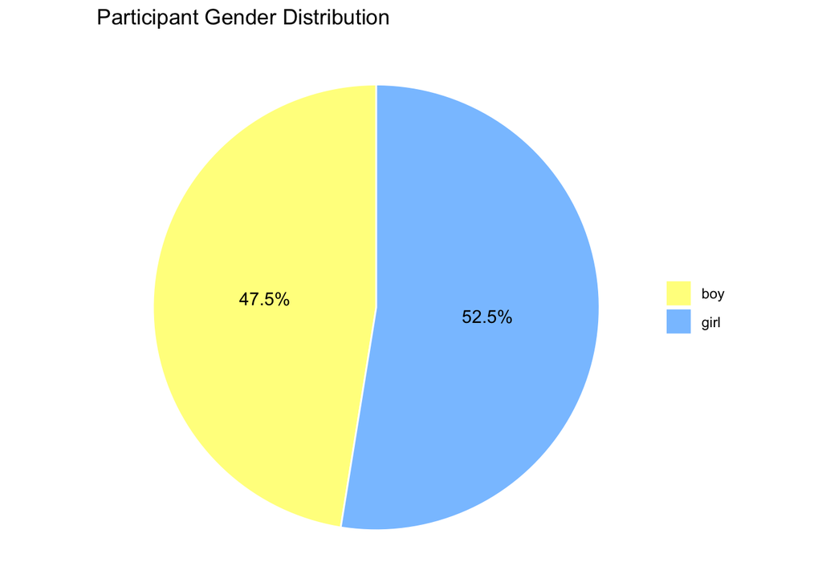

```r
ggplot(as.data.frame(table(thesis_partial$Gender)), aes(x = "", y = Freq, fill = Var1)) +
  geom_bar(stat = "identity", width = 1, color = "white") +
  coord_polar(theta = "y") +
  theme_void() +
  theme(legend.title = element_blank()) +
  ggtitle("Participant Gender Distribution") +
  geom_text(aes(label = paste0(round(Freq / sum(Freq) * 100, 1), "%")),
            position = position_stack(vjust = 0.5)) +
  scale_fill_manual(values = c("boy" = "#fffd8d", "girl" = "#89c4ff"))
```

From the table and pie chart, there are 13 6-year-olds (22%), 16 7-year-olds (27.1%), 13 8-year-olds (22%), 8 9-year-olds (13.6%), and 9 10-year-old (15.3%) who participated in the study.

```r
## demographic breakdown for participants - gender

table(thesis_partial$`Age (CALCULATED FROM PREVIOUS COLUMNS)`)
```

```
##
##  6  7  8  9 10
## 13 16 13  8  9
```

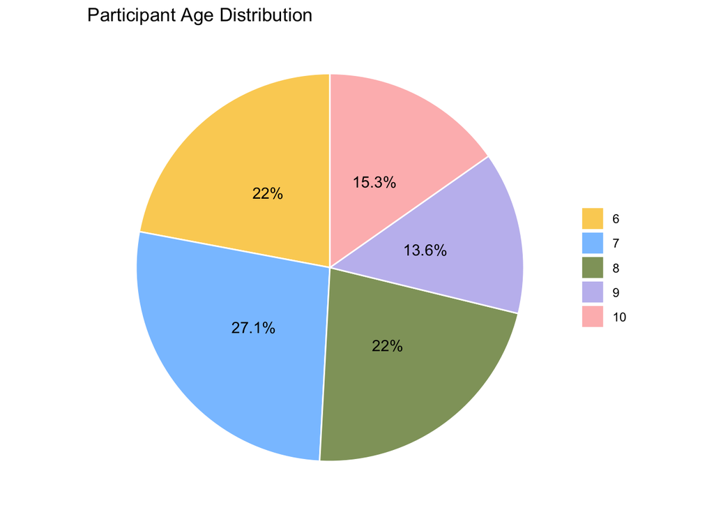

```r
ggplot(as.data.frame(table(thesis_partial$`Age (CALCULATED FROM PREVIOUS COLUMNS)`)), aes(x = "", y = Freq, fill = Var1)) +
  geom_bar(stat = "identity", width = 1, color = "white") +
  coord_polar(theta = "y") +
  theme_void() +
  theme(legend.title = element_blank()) +
  ggtitle("Participant Age Distribution") +
  geom_text(aes(label = paste0(round(Freq / sum(Freq) * 100, 1), "%")),
            position = position_stack(vjust = 0.5)) +
  scale_fill_manual(values = c("6" = "#fbd163", "7" = "#89c4ff", "8" = "#90a16a", "9" = "#c3beef", "10" = "#fdbcbc"))
```

```r
## demographic breakdown for participants - race

table(thesis_partial$Race)
```

```
##
##                    A                 A, W                    B
##                   11                    1                    3
## chose not to respond                    W                 W, A
##                    1                   35                    4
##                 W, H
##                    4
```

```r
## from the table, we can see that some RAs accidentally entered A, W instead of W, A, both of which mean that the participants are multiracial White and Asian. We will also want to count participant who identify White and Hispanic as Latinx/Hispanic. Therefore, we are creating a new race variable here.

thesis_partial <- thesis_partial %>%
  mutate(
    RaceCategory = case_when(
      Race %in% c("A, W", "W, A") ~ "Multiracial",  # Mark A, W or W, A as Multiracial
      Race %in% c("W, H") ~ "Latinx/Hispanic",  # Mark W, H as Latinx/Hispanic
      Race == "W" ~ "White",  # Mark W as White
      Race == "A" ~ "Asian",  # Mark A as Asian
      Race == "B" ~ "Black", # Mark B as Black
      Race == "Chose not to respond" ~ "Choose not to respond",  # Keep as is
      TRUE ~ NA_character_  # If none of the conditions match, assign NA
    )
  )

# Check the results
table(thesis_partial$RaceCategory)
```

```
##
##           Asian           Black Latinx/Hispanic     Multiracial           White
##              11               3               4               5              35
```

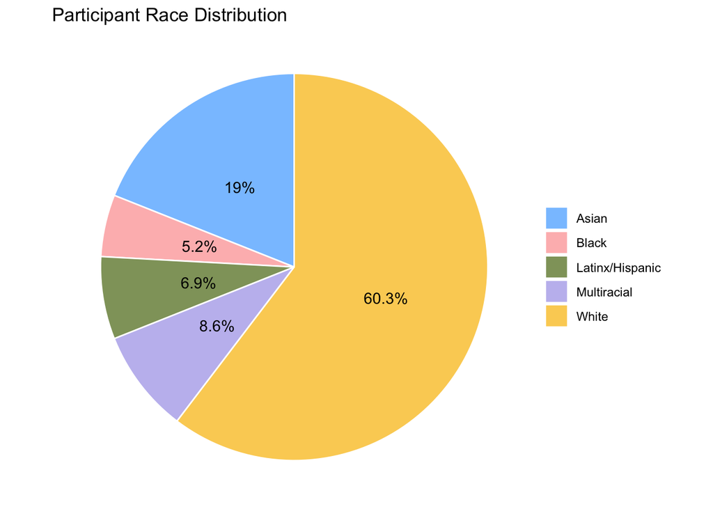

```r
## create the pie chart

ggplot(as.data.frame(table(thesis_partial$RaceCategory)), aes(x = "", y = Freq, fill = Var1)) +
  geom_bar(stat = "identity", width = 1, color = "white") +
  coord_polar(theta = "y") +
  theme_void() +
  theme(legend.title = element_blank()) +
  ggtitle("Participant Race Distribution") +
  geom_text(aes(label = paste0(round(Freq / sum(Freq) * 100, 1), "%")),
            position = position_stack(vjust = 0.5)) +
  scale_fill_manual(values = c("White" = "#fbd163", "Black" = "#fdbcbc", "Asian" = "#89c4ff", "Latinx/Hispanic" = "#90a16a", "Multiracial" = "#c3beef", "Choose not to respond" = "#fdbcbc"))
```